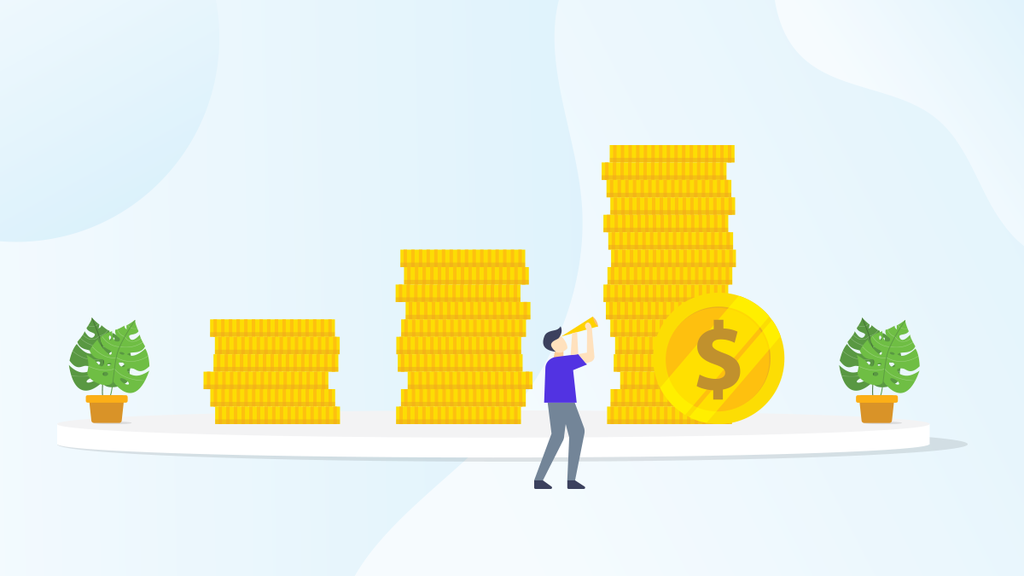

# LTV forecast with classification models

### Background

*Flaw in identifying profitable customers*

Marketers commonly estimate customer lifetime value in order to decide which customers are worth continued investment. In the previous project, I identified the best customers using RFM analysis based on historical data. However, I might have overlooked the real option of abandoning unprofitable customer since what I had been using was past figures. That is, the customers that you decided not bother aquiring might be actually profitable in the future.

*Find the customers who are valuable in the future*

We might want to identify the future profitable segment for a set of customers using the RFM approach and machine learning models. This helps us pinpoint the potential profitable customers so we could direct marketing dollars to the right customers.

### Objective

To identify the most profitable customer segment in the future among existing customers who have a known transaction history

### Approach

**LTV = revenue - cost^**

1. Period: Define a timeframe for LTV calculation -> Lets say 1 year as the timeframe

> Since I have 2 years of data available, I will set the middle point as threshold date:
> - Orders before the threshold date: used to train the model (for preparing the feature set)
> - Orders after the threshold date: used to compute the target value (LTV cluster)
1. Feature set: Compute the RFM scores for each customer and use the scores as the feature set
2. LTV prediction: Use multiclass classfication models to predict 1-year LTV segment for each customer and find the most profitable segment

*^Remark: there is no cost value in the given dataset, assuming cost=0 in this notebook.*

### Steps

1. Load & clean the data
2. Split the dataframe with threshold date into 2 partitions (1st year & 2nd year)
3. Prepare feature set by computing RFM scores using K-means Clustering (1st year data)
> - Recency: number of days since most recent purchase date
> - Frequency: number of transactions within the period
> - Monetary: total sales attributed to the customer
1. Data preprocessing
2. Build classification models and evaluate model performance
3. Hyperparamenter tuning to improve model performance
4. Conclusion

============================================================================

#### About the dataset

This Online Retail II data set contains all the transactions occurring for a UK-based and registered, non-store online retail between 01/12/2009 and 09/12/2011.The company mainly sells unique all-occasion gift-ware. Many customers of the company are wholesalers.

#### Column Descriptors

- InvoiceNo: Invoice number. Nominal. A 6-digit integral number uniquely assigned to each transaction. If this code starts with - the letter 'c', it indicates a cancellation.
- StockCode: Product (item) code. Nominal. A 5-digit integral number uniquely assigned to each distinct product.
- Description: Product (item) name. Nominal.
- Quantity: The quantities of each product (item) per transaction. Numeric.
- InvoiceDate: Invice date and time. Numeric. The day and time when a transaction was generated.
- UnitPrice: Unit price. Numeric. Product price per unit in sterling (Â£).
- CustomerID: Customer number. Nominal. A 5-digit integral number uniquely assigned to each customer.
- Country: Country name. Nominal. The name of the country where a customer resides.

*Data Source: https://www.kaggle.com/mathchi/online-retail-ii-data-set-from-ml-repository*

*Reference:*

- *https://towardsdatascience.com/data-driven-growth-with-python-part-3-customer-lifetime-value-prediction-6017802f2e0f*
- *https://cloud.google.com/architecture/clv-prediction-with-offline-training-intro#:~:text=CLV%20modeling%20can%20help%20you,much%20to%20invest%20in%20advertising.*
- *https://hbr.org/2007/12/the-flaw-in-customer-lifetime-value*
- *https://towardsdatascience.com/churn-prediction-with-machine-learning-c9124d932174*
- *https://developers.google.com/machine-learning/crash-course/classification/precision-and-recall*
- *https://datascience.stackexchange.com/questions/15989/micro-average-vs-macro-average-performance-in-a-multiclass-classification-settin*
- *https://towardsdatascience.com/scale-standardize-or-normalize-with-scikit-learn-6ccc7d176a02*

```python
import pandas as pd
import numpy as np
import seaborn as sns
import matplotlib.pyplot as plt
%matplotlib inline
%config InlineBackend.figure_format = 'retina'
```

```python
plt.style.use('seaborn')
```

```python
import warnings
warnings.filterwarnings("ignore")
```

```python
from sklearn.model_selection import train_test_split
from sklearn.model_selection import cross_validate
from sklearn.model_selection import GridSearchCV

from sklearn.svm import SVC
from sklearn.ensemble import RandomForestClassifier
from xgboost import XGBClassifier

from sklearn.metrics import classification_report
```

### 1. Data Cleaning

**Load the dataset**

```python
df = pd.read_excel('online_retail_II.xlsx',sheet_name='Year 2009-2010')
```

```python
df_org = df.copy()
```

```python
df1 = pd.read_excel('online_retail_II.xlsx',sheet_name='Year 2010-2011')
```

```python
df1_org = df1.copy()
```

```python
df.head(2)
```

|  | Invoice | StockCode | Description | Quantity | InvoiceDate | Price | Customer ID | Country |
| --- | --- | --- | --- | --- | --- | --- | --- | --- |
| 0 | 489434 | 85048 | 15CM CHRISTMAS GLASS BALL 20 LIGHTS | 12 | 2009-12-01 07:45:00 | 6.95 | 13085.0 | United Kingdom |
| 1 | 489434 | 79323P | PINK CHERRY LIGHTS | 12 | 2009-12-01 07:45:00 | 6.75 | 13085.0 | United Kingdom |

```python
print('date range for df: ',df.InvoiceDate.min(),' to ',df.InvoiceDate.max())
```

```
date range for df:  2009-12-01 07:45:00  to  2010-12-09 20:01:00
```

```python
print('date range for df1: ',df1.InvoiceDate.min(),' to ',df1.InvoiceDate.max())
```

```
date range for df1:  2010-12-01 08:26:00  to  2011-12-09 12:50:00
```

**Combine 2 tables**

To avoid duplication, I will remove data after 2010-11-30 in **df dataset**, then combine the 2 dataset.

```python
df[df.InvoiceDate>'2010-12-01'].shape
```

```
(22523, 8)
```

```python
df1[df1.InvoiceDate<'2010-12-10'].shape
```

```
(22523, 8)
```

```python
df = df[~(df['InvoiceDate']>'2010-12-01')]
```

```python
print('date range for df: ',df.InvoiceDate.min(),' to ',df.InvoiceDate.max())
```

```
date range for df:  2009-12-01 07:45:00  to  2010-11-30 19:35:00
```

```python
#combine the 2 tables

df = pd.concat([df,df1])

print('date range for df: ',df.InvoiceDate.min(),' to ',df.InvoiceDate.max())
```

```
date range for df:  2009-12-01 07:45:00  to  2011-12-09 12:50:00
```

**Convert the date format to YYYY-MM-DD**

```python
#convert the date format to YYYY-MM-DD (removing time)
df['InvoiceDate'] = df['InvoiceDate'].astype('datetime64[D]')
```

```python
# find the observation point
df['InvoiceDate'].max()
```

```
Timestamp('2011-12-09 00:00:00')
```

**Handle missing values**

```python
df.isnull().sum()
```

```
Invoice             0
StockCode           0
Description      4275
Quantity            0
InvoiceDate         0
Price               0
Customer ID    235287
Country             0
dtype: int64
```

```python
df.dropna(subset=['Customer ID'],inplace=True)
```

```python
df.isnull().sum()
```

```
Invoice        0
StockCode      0
Description    0
Quantity       0
InvoiceDate    0
Price          0
Customer ID    0
Country        0
dtype: int64
```

```python
df = df.reset_index(drop=True)
```

```python
df.shape
```

```
(809561, 8)
```

```python
df.describe()
```

|  | Quantity | Price | Customer ID |
| --- | --- | --- | --- |
| count | 809561.000000 | 809561.000000 | 809561.000000 |
| mean | 12.460672 | 3.685980 | 15319.760422 |
| std | 190.301161 | 70.876558 | 1695.812057 |
| min | -80995.000000 | 0.000000 | 12346.000000 |
| 25% | 2.000000 | 1.250000 | 13969.000000 |
| 50% | 5.000000 | 1.950000 | 15248.000000 |
| 75% | 12.000000 | 3.750000 | 16792.000000 |
| max | 80995.000000 | 38970.000000 | 18287.000000 |

```python
df.info()
```

```
<class 'pandas.core.frame.DataFrame'>
RangeIndex: 809561 entries, 0 to 809560
Data columns (total 8 columns):
 #   Column       Non-Null Count   Dtype
---  ------       --------------   -----
 0   Invoice      809561 non-null  object
 1   StockCode    809561 non-null  object
 2   Description  809561 non-null  object
 3   Quantity     809561 non-null  int64
 4   InvoiceDate  809561 non-null  datetime64[ns]
 5   Price        809561 non-null  float64
 6   Customer ID  809561 non-null  float64
 7   Country      809561 non-null  object
dtypes: datetime64[ns](1), float64(2), int64(1), object(4)
memory usage: 49.4+ MB
```

### 2. Split the dataframe

The dataset consists of 2 years of transaction data from 2009-12-01 to 2011-12-09. I will take 1 year of data, calculate RFM and use it for predicting next year.

- Threshold date: 2010-12-01
- 1st data set: 2009-12-01 to 2010-11-30 (feature set to train the models)
- 2nd data set: 2010-12-01 to 2011-11-30 (containing target values)

```python
df_1styear = df[(df.InvoiceDate > '2009-12-01')&(df.InvoiceDate < '2010-11-30')]
df_2ndyear = df[(df.InvoiceDate > '2010-12-01')&(df.InvoiceDate < '2011-11-30')]
```

### 3. Compute RFM scores using K-means Clustering as feature set

**Caculate the RFM values**

Based on the 1st year dataset(df_1styear), I will set the most recent date in the dataset as the observation point to caculate the recency.

- Recency = observation point - most recent transaction date
- Frequency = #invoice counts within the period
- Monetary = Sum of transaction value for each customer (transaction value = Quantity * Price)

```python
#Create the dataframe with unique customer ID and the most recent date for each customer
df_user = df_1styear.groupby('Customer ID')['InvoiceDate'].max().reset_index()
df_user.columns=['CustomerID','MostRecentInvoiceDate']

# Calculate the recency for each customer
# Recency = observation point - transaction date
df_user['Recency'] = df_1styear['InvoiceDate'].max() - df_user.MostRecentInvoiceDate

#convert Recency to integer format
df_user['Recency'] = pd.to_timedelta(df_user.Recency, errors='coerce').dt.days

#drop the 'most recent date' column
df_user.drop('MostRecentInvoiceDate',axis=1,inplace=True)

#Create the dataframe with unique customer ID and the frquency for each customer
df_freq = df_1styear.groupby('Customer ID')['InvoiceDate'].count().reset_index()
df_freq.columns=['CustomerID','Frequency']

#Calculate the total transaction amount for each customer and store the value in new column
df_1styear['TotalAmount'] = df_1styear.Quantity*df_1styear.Price

#Create the dataframe with unique customer ID and the total transaction amount for each customer
df_money = df_1styear.groupby('Customer ID')['TotalAmount'].sum().reset_index()
df_money.columns=['CustomerID','Monetary']

#Merge the tables to create a single table containing RFM columns
df_user = df_user.merge(df_freq,on='CustomerID')
df_user = df_user.merge(df_money,on='CustomerID')

df_user.head()
```

|  | CustomerID | Recency | Frequency | Monetary |
| --- | --- | --- | --- | --- |
| 0 | 12346.0 | 56 | 46 | -64.68 |
| 1 | 12347.0 | 29 | 40 | 611.53 |
| 2 | 12348.0 | 63 | 20 | 222.16 |
| 3 | 12349.0 | 32 | 107 | 2646.99 |
| 4 | 12351.0 | 0 | 21 | 300.93 |

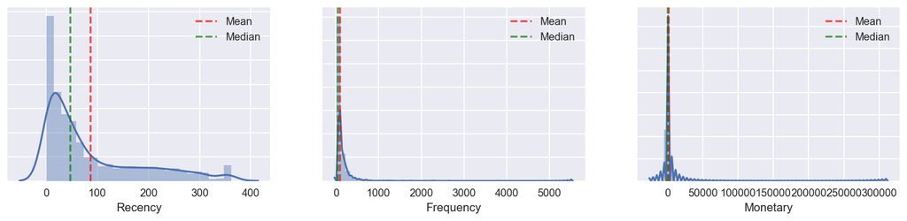

```python
fig,ax = plt.subplots(1,3,figsize=(15,3))

r_mean = df_user.Recency.mean()
r_median = df_user.Recency.median()
f_mean = df_user.Frequency.mean()
f_median = df_user.Frequency.median()
m_mean = df_user.Monetary.mean()
m_median = df_user.Monetary.median()

sns.distplot(df_user.Recency,ax=ax[0])
ax[0].axvline(x=r_mean,color='r',linestyle='--',alpha=0.7)
ax[0].axvline(x=r_median,color='g',linestyle='--',alpha=0.7)
ax[0].set(yticklabels=[])
ax[0].legend({'Mean':r_mean,'Median':r_median})

sns.distplot(df_user.Frequency ,ax=ax[1])
ax[1].axvline(x=f_mean,color='r',linestyle='--',alpha=0.7)
ax[1].axvline(x=f_median,color='g',linestyle='--',alpha=0.7)
ax[1].set(yticklabels=[])
ax[1].legend({'Mean':r_mean,'Median':r_median})

sns.distplot(df_user.Monetary,ax=ax[2])
ax[2].axvline(x=m_mean,color='r',linestyle='--',alpha=0.7)
ax[2].axvline(x=m_median,color='g',linestyle='--',alpha=0.7)
ax[2].set(yticklabels=[])

ax[2].legend({'Mean':r_mean,'Median':r_median})
```

```python
df_user[['Recency','Frequency','Monetary']].describe()
```

|  | Recency | Frequency | Monetary |
| --- | --- | --- | --- |
| count | 4320.000000 | 4320.000000 | 4320.000000 |
| mean | 86.871296 | 92.168981 | 1841.527612 |
| std | 95.302096 | 197.201304 | 8138.461708 |
| min | 0.000000 | 1.000000 | -25111.090000 |
| 25% | 15.000000 | 18.000000 | 283.370000 |
| 50% | 47.000000 | 43.000000 | 642.640000 |
| 75% | 134.000000 | 100.000000 | 1586.940000 |
| max | 362.000000 | 5519.000000 | 311655.880000 |

The median values of Recency, Frequency and Monetary are all smaller than Mean values. Their distributions **skewed to right.**

**Compute the RFM scores with K-means clustering**

The higher scores should indicate better values, i.e. lower recency value should have higher Recency score; higher frequency value should have higher frequency score; higher monetary value should have higher monetary score.

From previous project, the optimal #clusters was 4 which would be set as the parameter for K-means clustering, i.e. scoring will be 0 to 3.

```python
from sklearn.cluster import KMeans
```

```python
#K-means clustering, using n_clusters = 4 which is the optimal value determinded in previous RFM project.
kmeans = KMeans(n_clusters=4,init='k-means++')

#Create cluster column with respect to RFM value
df_user['RecencyCluster'] = kmeans.fit_predict(df_user[['Recency']])
df_user['FrequencyCluster'] = kmeans.fit_predict(df_user[['Frequency']])
df_user['MonetaryCluster'] = kmeans.fit_predict(df_user[['Monetary']])

#function to reorder the cluster number so that higher score indicates better value
def cluster_reorder(df,cluster_field,RFM_value_field,ascending_boolean):
    df_order = df.groupby(cluster_field)[RFM_value_field].mean().sort_values(ascending=ascending_boolean).reset_index()
    df_order['new_cluster'] = df_order.index
    df_order.drop(RFM_value_field,axis=1,inplace=True)

    df = df.merge(df_order,how='left',on=cluster_field)

    df.drop(cluster_field,axis=1,inplace=True)
    df.rename(columns={'new_cluster':cluster_field},inplace=True)
    return df

#Apply the re-order function to RFM clusters
df_user = cluster_reorder(df_user,'RecencyCluster','Recency',False)
df_user = cluster_reorder(df_user,'FrequencyCluster','Frequency',True)
df_user = cluster_reorder(df_user,'MonetaryCluster','Monetary',True)

#describe the Recency cluster profile
df_user.groupby(['RecencyCluster'])['Recency'].describe().T
```

| RecencyCluster | 0 | 1 | 2 | 3 |
| --- | --- | --- | --- | --- |
| count | 474.000000 | 646.000000 | 1042.000000 | 2158.000000 |
| mean | 295.820675 | 181.868421 | 75.753359 | 17.906858 |
| std | 39.514596 | 31.396732 | 22.969629 | 13.388878 |
| min | 242.000000 | 129.000000 | 47.000000 | 0.000000 |
| 25% | 259.000000 | 154.000000 | 56.000000 | 6.000000 |
| 50% | 291.000000 | 180.000000 | 69.500000 | 15.000000 |
| 75% | 326.000000 | 208.000000 | 94.000000 | 27.000000 |
| max | 362.000000 | 237.000000 | 127.000000 | 46.000000 |

```python
df_user.groupby(['FrequencyCluster'])['Frequency'].describe().T
```

| FrequencyCluster | 0 | 1 | 2 | 3 |
| --- | --- | --- | --- | --- |
| count | 3832.000000 | 463.000000 | 22.000000 | 3.000000 |
| mean | 50.893528 | 336.047516 | 1514.000000 | 4749.333333 |
| std | 45.863104 | 144.265710 | 495.768859 | 870.247283 |
| min | 1.000000 | 194.000000 | 967.000000 | 3805.000000 |
| 25% | 16.000000 | 231.500000 | 1147.750000 | 4364.500000 |
| 50% | 36.000000 | 283.000000 | 1300.000000 | 4924.000000 |
| 75% | 75.000000 | 393.000000 | 1750.750000 | 5221.500000 |
| max | 193.000000 | 904.000000 | 2649.000000 | 5519.000000 |

```python
df_user.groupby(['MonetaryCluster'])['Monetary'].describe().T
```

| MonetaryCluster | 0 | 1 | 2 | 3 |
| --- | --- | --- | --- | --- |
| count | 4264.000000 | 51.000000 | 3.000000 | 2.000000 |
| mean | 1278.922416 | 29605.162216 | 147220.016667 | 275275.390000 |
| std | 1928.169088 | 15598.358011 | 30058.995322 | 51449.782364 |
| min | -25111.090000 | 15706.000000 | 127330.300000 | 238894.900000 |
| 25% | 280.272500 | 18368.970000 | 129930.500000 | 257085.145000 |
| 50% | 632.695000 | 22170.650000 | 132530.700000 | 275275.390000 |
| 75% | 1542.167500 | 36745.455000 | 157164.875000 | 293465.635000 |
| max | 15133.030000 | 80366.240000 | 181799.050000 | 311655.880000 |

**Total score**

Sum up all RFM scores to get an overall score for each customer

```python
df_user['TotalScore'] = df_user.RecencyCluster + df_user.FrequencyCluster + df_user.MonetaryCluster
```

```python
#compute the median of RFM values for each total score level
df_user.groupby('TotalScore').median().iloc[:,1:]
```

| TotalScore | Recency | Frequency | Monetary | RecencyCluster | FrequencyCluster | MonetaryCluster |
| --- | --- | --- | --- | --- | --- | --- |
| 0 | 291.0 | 15.0 | 215.130 | 0.0 | 0.0 | 0.0 |
| 1 | 180.0 | 23.0 | 329.490 | 1.0 | 0.0 | 0.0 |
| 2 | 70.0 | 39.0 | 624.430 | 2.0 | 0.0 | 0.0 |
| 3 | 18.0 | 55.0 | 836.950 | 3.0 | 0.0 | 0.0 |
| 4 | 11.0 | 289.0 | 3875.345 | 3.0 | 1.0 | 0.0 |
| 5 | 5.0 | 474.0 | 19289.370 | 3.0 | 1.0 | 1.0 |
| 6 | 2.5 | 1270.5 | 27092.505 | 3.0 | 2.0 | 1.0 |
| 7 | 3.0 | 2649.0 | 127330.300 | 3.0 | 2.0 | 2.0 |
| 8 | 0.0 | 3636.0 | 185712.800 | 3.0 | 2.5 | 2.5 |

**Segment customers into high, mid, low value based on total score**

- high-value: total score = 6 to 8
- mid-value: total score = 3 to 5
- low-value: total score = 0 to 2

```python
df_user['Segment'] = 'low-value'
df_user.loc[df_user['TotalScore']>=3,['Segment']] = 'mid-value'
df_user.loc[df_user['TotalScore']>=6,['Segment']] = 'high-value'
```

```python
df_user.head()
```

|  | CustomerID | Recency | Frequency | Monetary | RecencyCluster | FrequencyCluster | MonetaryCluster | TotalScore | Segment |
| --- | --- | --- | --- | --- | --- | --- | --- | --- | --- |
| 0 | 12346.0 | 56 | 46 | -64.68 | 2 | 0 | 0 | 2 | low-value |
| 1 | 12347.0 | 29 | 40 | 611.53 | 3 | 0 | 0 | 3 | mid-value |
| 2 | 12348.0 | 63 | 20 | 222.16 | 2 | 0 | 0 | 2 | low-value |
| 3 | 12349.0 | 32 | 107 | 2646.99 | 3 | 0 | 0 | 3 | mid-value |
| 4 | 12351.0 | 0 | 21 | 300.93 | 3 | 0 | 0 | 3 | mid-value |

```python
df_user.groupby('Segment').median().sort_values('TotalScore').iloc[:,1:]
```

| Segment | Recency | Frequency | Monetary | RecencyCluster | FrequencyCluster | MonetaryCluster | TotalScore |
| --- | --- | --- | --- | --- | --- | --- | --- |
| low-value | 138 | 26 | 382.79 | 1 | 0 | 0 | 1 |
| mid-value | 15 | 75 | 1116.61 | 3 | 0 | 0 | 3 |
| high-value | 1 | 1540 | 39626.87 | 3 | 2 | 1 | 6 |

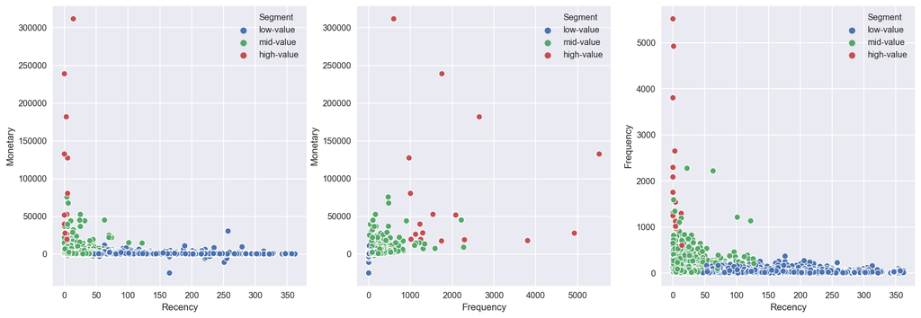

```python
#to examine the RFM values among segments
f,ax = plt.subplots(1,3,figsize=(18,6))
f.subplots_adjust(wspace=.2,hspace=.1)

sns.scatterplot(data=df_user,x='Recency',y='Monetary',hue='Segment',ax=ax[0])
sns.scatterplot(data=df_user,x='Frequency',y='Monetary',hue='Segment',ax=ax[1])
sns.scatterplot(data=df_user,x='Recency',y='Frequency',hue='Segment',ax=ax[2])
```

### 4. Data preprocessing

**2nd dataset to show only customer IDs and monetary values**

```python
#Calculate the total transaction amount for each customer and store the value in new column
df_2ndyear['TotalAmount'] = df_2ndyear.Quantity*df_2ndyear.Price

#Create the dataframe with unique customer ID and the total transaction amount for each customer
df_user_2ndyear = df_2ndyear.groupby('Customer ID')['TotalAmount'].sum().reset_index()
df_user_2ndyear.columns=['CustomerID','Monetary_2ndyear']
```

**Merge the 2 datasets w/ customer ID**

- 1st year data: customer IDs + RFM values + RFM scores + total score + segment
- 2nd year data: customer IDs + Monetary values

```python
#merge 1st yr and 2nd yr data
df_merge = df_user.merge(df_user_2ndyear,how='left',on='CustomerID')

df_merge.head()
```

|  | CustomerID | Recency | Frequency | Monetary | RecencyCluster | FrequencyCluster | MonetaryCluster | TotalScore | Segment | Monetary_2ndyear |
| --- | --- | --- | --- | --- | --- | --- | --- | --- | --- | --- |
| 0 | 12346.0 | 56 | 46 | -64.68 | 2 | 0 | 0 | 2 | low-value | 0.00 |
| 1 | 12347.0 | 29 | 40 | 611.53 | 3 | 0 | 0 | 3 | mid-value | 4085.18 |
| 2 | 12348.0 | 63 | 20 | 222.16 | 2 | 0 | 0 | 2 | low-value | 1797.24 |
| 3 | 12349.0 | 32 | 107 | 2646.99 | 3 | 0 | 0 | 3 | mid-value | 1757.55 |
| 4 | 12351.0 | 0 | 21 | 300.93 | 3 | 0 | 0 | 3 | mid-value | NaN |

**Fill NA monetary values**

2nd dataset has NA monetary values, which means the customer appearing in 1st dataset didn't spend in 2nd year. Will replace those NA values to 0.

```python
df_merge['Monetary_2ndyear'].fillna(0,inplace=True)
```

**Outliers handling**

There are few outliers which affect the machine learning model performance. Gonna remove them.

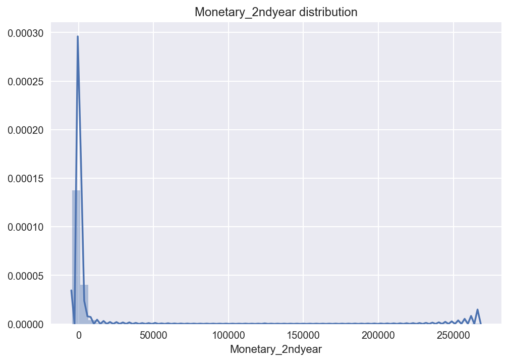

```python
g = sns.distplot(df_merge['Monetary_2ndyear'])
g.set_title('Monetary_2ndyear distribution')
```

```python
df_merge = df_merge[df_merge['Monetary_2ndyear'] <50000]
```

**Remove negative monetary values**

Those negative numbers create noisy to the model and I am going to remove them too.

```python
df_merge = df_merge[df_merge['Monetary_2ndyear'] >=0]
```

**Segment the customers by monetary values w/ Kmeans clustering**

We will group customers into 3 segments based on monetary values in 2nd year

- High LTV --> cluster 2
- Mid LTV --> cluster 1
- Low LTV --> cluster 0

```python
#n_clusters = 3 for 3 segments
kmeans = KMeans(n_clusters=3,init='k-means++')
df_merge['LTVcluster_1yr'] = kmeans.fit_predict(df_merge[['Monetary_2ndyear']])

#reorder the cluster no with the re-order function
df_merge = cluster_reorder(df_merge,'LTVcluster_1yr','Monetary_2ndyear',True)

#show monetary values details for each LTV cluster
df_merge.groupby(['LTVcluster_1yr'])['Monetary_2ndyear'].describe().T.round()
```

| LTVcluster_1yr | 0 | 1 | 2 |
| --- | --- | --- | --- |
| count | 3974.0 | 277.0 | 16.0 |
| mean | 615.0 | 7251.0 | 33519.0 |
| std | 878.0 | 3449.0 | 8369.0 |
| min | 0.0 | 3948.0 | 23827.0 |
| 25% | 0.0 | 4669.0 | 27718.0 |
| 50% | 228.0 | 6004.0 | 32037.0 |
| 75% | 871.0 | 8911.0 | 35198.0 |
| max | 3919.0 | 19964.0 | 49957.0 |

Cluster 2 refers to the best customers with highest 2nd year monetary values, while Cluster 0 is the worst with lowest monetary values.

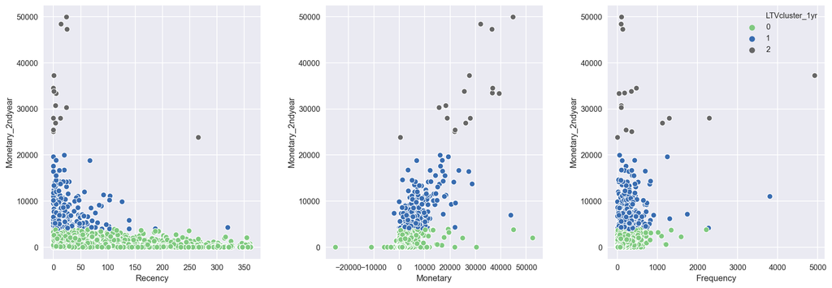

```python
#to examine the RFM values among segments
f,ax = plt.subplots(1,3,figsize=(18,6))
f.subplots_adjust(wspace=.3,hspace=.1)

sns.scatterplot(data=df_merge,x='Recency',y='Monetary_2ndyear',hue='LTVcluster_1yr',ax=ax[0],palette='Accent')
ax[0].legend("")

sns.scatterplot(data=df_merge,x='Monetary',y='Monetary_2ndyear',hue='LTVcluster_1yr',ax=ax[1],palette='Accent')
ax[1].legend("")

sns.scatterplot(data=df_merge,x='Frequency',y='Monetary_2ndyear',hue='LTVcluster_1yr',ax=ax[2],palette='Accent')
```

X-axis refers to the RFM values in the first year, and y-axis indicates the monetary values in the 2nd year in different colors to present the LTV clusters.

- Left: Most of the time high LTV segment had low recency values; while low LTV seg had broad recency pattern.
- Middle: Customers having high money spent in 1st year might or might not spend a lot in 2nd year. Some customers did not spend much in first year turned to spend quite a lot in 2nd year.
- Right:hard to spot out for frequency as most of the points concentrated below 1000.

**Convert categorical columns to numerical**

Since the ML models to be applied will only accept numerical variables, we have to convert the categorical variables to numbers. In our dataset we will convert 'Segment' cloumn to numbers.

- Dummy encoding: transform the categorical variable into a set of binary variables (also known as dummy variables).

```python
df_merge = pd.get_dummies(df_merge)

df_merge.head()
```

|  | CustomerID | Recency | Frequency | Monetary | RecencyCluster | FrequencyCluster | MonetaryCluster | TotalScore | Monetary_2ndyear | LTVcluster_1yr | Segment_high-value | Segment_low-value | Segment_mid-value |
| --- | --- | --- | --- | --- | --- | --- | --- | --- | --- | --- | --- | --- | --- |
| 0 | 12346.0 | 56 | 46 | -64.68 | 2 | 0 | 0 | 2 | 0.00 | 0 | 0 | 1 | 0 |
| 1 | 12347.0 | 29 | 40 | 611.53 | 3 | 0 | 0 | 3 | 4085.18 | 1 | 0 | 0 | 1 |
| 2 | 12348.0 | 63 | 20 | 222.16 | 2 | 0 | 0 | 2 | 1797.24 | 0 | 0 | 1 | 0 |
| 3 | 12349.0 | 32 | 107 | 2646.99 | 3 | 0 | 0 | 3 | 1757.55 | 0 | 0 | 0 | 1 |
| 4 | 12351.0 | 0 | 21 | 300.93 | 3 | 0 | 0 | 3 | 0.00 | 0 | 0 | 0 | 1 |

**Correlation heatmap**

To show the correlation between features against the target value - LTVcluster_1yr.

```python
corr = df_merge.corr().iloc[1:,9].reset_index()
corr.columns=['Features','LTVcluster_1yr']
corr = corr.set_index('Features').sort_values(by='LTVcluster_1yr',ascending=False)

#use seaborn to create heatmap
cm = sns.light_palette('skyblue', as_cmap=True)

s = corr.style.background_gradient(cmap=cm)
s
```

| Features | LTVcluster_1yr |
| --- | --- |
| LTVcluster_1yr | 1.000000 |
| Monetary_2ndyear | 0.807452 |
| Monetary | 0.580225 |
| MonetaryCluster | 0.394010 |
| Frequency | 0.376482 |
| FrequencyCluster | 0.350440 |
| TotalScore | 0.291970 |
| Segment_high-value | 0.206595 |
| Segment_mid-value | 0.182582 |
| RecencyCluster | 0.181165 |
| Recency | -0.179058 |
| Segment_low-value | -0.200469 |

Monetary features are mostly correlated with LTV cluster.

**Prepare X and y data**

```python
#final check for any null values
df_merge.isnull().sum()
```

```
CustomerID            0
Recency               0
Frequency             0
Monetary              0
RecencyCluster        0
FrequencyCluster      0
MonetaryCluster       0
TotalScore            0
Monetary_2ndyear      0
LTVcluster_1yr        0
Segment_high-value    0
Segment_low-value     0
Segment_mid-value     0
dtype: int64
```

```python
#Prepare X and Y da
X = df_merge.drop(['CustomerID','Monetary_2ndyear','LTVcluster_1yr'],axis=1)
y = df_merge['LTVcluster_1yr']
```

```python
X.columns
```

```
Index(['Recency', 'Frequency', 'Monetary', 'RecencyCluster',
       'FrequencyCluster', 'MonetaryCluster', 'TotalScore',
       'Segment_high-value', 'Segment_low-value', 'Segment_mid-value'],
      dtype='object')
```

```python
X.shape
```

```
(4267, 10)
```

### 5. Build classification models

**Models selected**

Will apply 3 classifiers and go for the one with best performance:

```
A. Support Vector Machine
B. Random Forest
C. XGBClassifier
```

**Precision vs Recall in evalutation**

Precision = TP/(TP+FP)

Precision trys to answer: what proportion of positive identifications was actually correct? If precision of the model is 50% for cluster 2, when the model predicts the customer is in high LTV segment, it is correct 50% of the time.

Recall = TP/(TP+FN)

Recall trys to answer: what proportion of actual positives was identified correctly? If recall is 50% for cluster 2, then the model correctly identifies 50% of high LTV customers.

I will use Recall to evaluate the model performance, as it gives a measure of how accurately the model is able to identify the actual high LTV customers.

**Stratified k-fold Cross Validation**

The default Cross Validation method being used here, which divides a limited dataset into k folds and enforces the class distribution in each split of the data to match the distribution in the complete training datset.

```python
#set up model variables
rf = RandomForestClassifier()
xgb = XGBClassifier()
svc = SVC()

#list to store model name and recall values
model_name = []
recall = []

#cross validate each model and output the mean recall value for each model (set #splits for kfold = 5)
for model in (rf,xgb,svc):

    model_name.append(model.__class__.__name__)

#compute the macro average of recall values across 3 classes as we valued the minority class (LTV cluster 2) the most
#get mean of recall values among 5 folds of data
    recall.append(cross_validate(model,X,y,cv=5,scoring='recall_macro')['test_score'].mean())

#comparison table to show model vs their mean recall value
pd.DataFrame({'model':model_name,'Recall':recall})
```

|  | model | Recall |
| --- | --- | --- |
| 0 | RandomForestClassifier | 0.610514 |
| 1 | XGBClassifier | 0.640087 |
| 2 | SVC | 0.333333 |

The selected models do not perform very well. Let's try to do hyperparameter tuning and see if the result will get better.

**Train Test dataset split**

70% of data will be used for model training and another 30% is used for model evaluation against unseen data(test).

```python
X_train,X_test,y_train,y_test = train_test_split(X,y,test_size=0.3,random_state=1)
```

### 6. Hyperparamenter tuning to improve model performance

We will try to improve the accuracy by tuning the hyperparameters for Random Forest and XGB, with grid search to get the optimized values of hyper parameters. The parameters to be adjusted is specified in param_grid below.

**Random Forest Classifier**

```python
#find the best parameters for RandomForestClassfier
param_grid = {'max_depth':list(range(1,20,2)),'n_estimators':list(range(1,500,50))}
grid_search = GridSearchCV(RandomForestClassifier(random_state=1),param_grid)
grid_search.fit(X_train,y_train)
grid_search.best_params_
```

```
{'max_depth': 9, 'n_estimators': 301}
```

```python
#apply the best parameter values to model
rfm = RandomForestClassifier(n_estimators=301,max_depth=9,random_state=1)

rfm.fit(X_train, y_train)
y_pred = rfm.predict(X_test)

print(classification_report(y_test, y_pred))
```

```
              precision    recall  f1-score   support

           0       0.96      0.99      0.97      1188
           1       0.73      0.44      0.55        87
           2       1.00      0.50      0.67         6

    accuracy                           0.95      1281
   macro avg       0.90      0.64      0.73      1281
weighted avg       0.94      0.95      0.94      1281
```

The recall macro avg value got improved after hyperparameters tuning.

**XGBClassifier**

```python
#find the best parameters for XGBClassfier
param_grid = {'max_depth':list(range(1,20,2)),'n_estimators':list(range(1,500,50))}
grid_search = GridSearchCV(XGBClassifier(random_state=1),param_grid)
grid_search.fit(X_train,y_train)
grid_search.best_params_
```

```
{'max_depth': 1, 'n_estimators': 401}
```

```python
#apply the best parameter values to model
xgb = XGBClassifier(n_estimators=401,max_depth=1,random_state=1).fit(X_train, y_train)

y_pred = xgb.predict(X_test)

print(classification_report(y_test, y_pred))
```

```
              precision    recall  f1-score   support

           0       0.96      0.99      0.97      1188
           1       0.70      0.46      0.56        87
           2       0.60      0.50      0.55         6

    accuracy                           0.95      1281
   macro avg       0.75      0.65      0.69      1281
weighted avg       0.94      0.95      0.94      1281
```

The recall macro avg value got improved after hyperparameters tuning.

**Support Vector Classifier**

```python
#assign some parameter values to the svc model
svc = SVC(kernel='linear',C=0.025,random_state=101)

svc.fit(X_train, y_train)

y_pred = svc.predict(X_test)

print(classification_report(y_test, y_pred))
```

```
              precision    recall  f1-score   support

           0       0.95      0.99      0.97      1188
           1       0.64      0.24      0.35        87
           2       0.75      0.50      0.60         6

    accuracy                           0.94      1281
   macro avg       0.78      0.58      0.64      1281
weighted avg       0.92      0.94      0.92      1281
```

From the above result, all of the selected models got 99% recall value when predicting cluster 0. However, for our mostly concerned group - cluster 2 (high LTV value), the models only got 50% in recall value. That means, among the actual high LTV customers, 50% of them could be detected by the models.

### 7. Conclusion

By forecasting LTV clusters, we are able to pinpoint the potential profitable customers and direct marketing dollars to the right customers.